# A primer for conducting a meta-analysis to synthesize correlational data

Enrico Perinelli

Department of Psychology and Cognitive Science, University of Trento

## Preliminary Information

In this exercise, we will use the meta-analysis provided by Molloy, O’Carroll, & Ferguson (2014) and the tutorial by Quintana (2015). In particular, the meta-analysis by Molloy et al. (2014) aimed to systematically estimate the strength and variability of the relation between **conscientiousness** (from the five-factor model of personality) and **adherence to medications** and to identify moderators of this relationship.

Here, the aim is to cover the main meta-analytic steps and calculations, by using the tutorial codes provided by Quintana (2015) with some integrations. The package used is `metafor`.

Some useful links:

- The paper by Quintana (2015) - https://www.frontiersin.org/articles/10.3389/fpsyg.2015.01549/full
- The paper by Molloy, O’Carroll, & Ferguson (2014) - https://academic.oup.com/abm/article/47/1/92/4563919
- YouTube tutorial - https://www.youtube.com/watch?v=d1pYHfCKhyA&t=558s
- The script and datasets (GitHub) - https://github.com/dsquintana/corr_meta
- The `metafor` package website - https://www.metafor-project.org/doku.php/plots

In what follows, I have reported the scripts provided by Quintana (2015), with some adaptations.

## Install and load packages

The code `install.packages(c("robumeta", "metafor", "dplyr"))` needs to be run just once

```r
# install.packages(c("robumeta", "metafor", "dplyr"))

library("robumeta")
library("metafor")
library("dplyr")
```

## Import your data

For the analyses described in Quintana 2015, the data is included with the metafor package. Use the following command to load the data. You are creating a new object called “dat” from the Molloy et al., (2014) data.

```r
dat <- get(data(dat.molloy2014))
dat <- mutate(dat, study_id = 1:16) # This adds a study id column
dat <- dat %>% select(study_id, authors:quality) # This brings the study id column to the front
```

### Take a look at the data

You should run `View(dat)` by removing the *#*

```r
# View(dat)

knitr::kable(dat, caption = "Our dataset")
```

Our dataset

| study_id | authors | year | ni | ri | controls | design | a_measure | c_measure | meanage | quality |
| --- | --- | --- | --- | --- | --- | --- | --- | --- | --- | --- |
| 1 | Axelsson et al. | 2009 | 109 | 0.187 | none | cross-sectional | self-report | other | 22.00 | 1 |
| 2 | Axelsson et al. | 2011 | 749 | 0.162 | none | cross-sectional | self-report | NEO | 53.59 | 1 |
| 3 | Bruce et al. | 2010 | 55 | 0.340 | none | prospective | other | NEO | 43.36 | 2 |
| 4 | Christensen et al. | 1999 | 107 | 0.320 | none | cross-sectional | self-report | other | 41.70 | 1 |
| 5 | Christensen & Smith | 1995 | 72 | 0.270 | none | prospective | other | NEO | 46.39 | 2 |
| 6 | Cohen et al. | 2004 | 65 | 0.000 | none | prospective | other | NEO | 41.20 | 2 |
| 7 | Dobbels et al. | 2005 | 174 | 0.175 | none | cross-sectional | self-report | NEO | 52.30 | 1 |
| 8 | Ediger et al. | 2007 | 326 | 0.050 | multiple | prospective | self-report | NEO | 41.00 | 3 |
| 9 | Insel et al. | 2006 | 58 | 0.260 | none | prospective | other | other | 77.00 | 2 |
| 10 | Jerant et al. | 2011 | 771 | 0.010 | multiple | prospective | other | NEO | 78.60 | 3 |
| 11 | Moran et al. | 1997 | 56 | -0.090 | multiple | prospective | other | NEO | 57.20 | 2 |
| 12 | O’Cleirigh et al. | 2007 | 91 | 0.370 | none | prospective | self-report | NEO | 37.90 | 2 |
| 13 | Penedo et al. | 2003 | 116 | 0.000 | none | cross-sectional | self-report | NEO | 39.20 | 1 |
| 14 | Quine et al. | 2012 | 537 | 0.150 | none | prospective | self-report | other | 69.00 | 2 |
| 15 | Stilley et al. | 2004 | 158 | 0.240 | none | prospective | other | NEO | 46.20 | 3 |
| 16 | Wiebe & Christensen | 1997 | 65 | 0.040 | none | prospective | other | NEO | 56.00 | 1 |

```r
dim(dat)
```

```
## [1] 16 11
```

```r
glimpse(dat)
```

```
## Rows: 16
## Columns: 11
## $ study_id  <int> 1, 2, 3, 4, 5, 6, 7, 8, 9, 10, 11, 12, 13, 14, 15, 16
## $ authors   <chr> "Axelsson et al.", "Axelsson et al.", "Bruce et al.", "Chris~
## $ year      <int> 2009, 2011, 2010, 1999, 1995, 2004, 2005, 2007, 2006, 2011, ~
## $ ni        <int> 109, 749, 55, 107, 72, 65, 174, 326, 58, 771, 56, 91, 116, 5~
## $ ri        <dbl> 0.187, 0.162, 0.340, 0.320, 0.270, 0.000, 0.175, 0.050, 0.26~
## $ controls  <chr> "none", "none", "none", "none", "none", "none", "none", "mul~
## $ design    <chr> "cross-sectional", "cross-sectional", "prospective", "cross-~
## $ a_measure <chr> "self-report", "self-report", "other", "self-report", "other~
## $ c_measure <chr> "other", "NEO", "NEO", "other", "NEO", "NEO", "NEO", "NEO", ~
## $ meanage   <dbl> 22.00, 53.59, 43.36, 41.70, 46.39, 41.20, 52.30, 41.00, 77.0~
## $ quality   <int> 1, 1, 2, 1, 2, 2, 1, 3, 2, 3, 2, 2, 1, 2, 3, 1
```

We can see that we have 16 rows (reports) and 11 columns (variables)

The data frame contains the following 11 columns:

| Var | Type | Explanation |
| --- | --- | --- |
| study_id | numeric | id for each study |
| authors | character | study authors |
| year | numeric | publication year |
| ni | numeric | sample size of the study |
| ri | numeric | observed correlation |
| controls | character | number of variables controlled for |
| design | character | whether a cross-sectional or prospective design was used |
| a_measure | character | type of adherence measure (self-report or other) |
| c_measure | character | type of conscientiousness measure (NEO or other) |
| meanage | numeric | mean age of the sample |
| quality | numeric | methodological quality |

## *r*-to-*z* transformation

The first step is to transform *r* to *Z* and calculate the corresponding sample variances, by means of the `escalc()` function.

“The reason that *r* is often transformed to *Z<sub>r</sub>* in meta-analyses is because the distribution of sample *r*’s around a given population ρ is skewed (except in sample sizes larger than those commonly seen in the social sciences), whereas a sample of *Z<sub>r</sub>s* around a population *Z<sub>r</sub>* is symmetric (for further details see Hedges & Olkin, 1985, pp. 226–228; Schulze, 2004, pp. 21–28). This symmetry is desirable when combining and comparing effect sizes across studies. However, *Z<sub>r</sub>* is less readily interpretable than *r* both because it is not bounded (i.e., it can have values greater than ±1.0) and simply because it is unfamiliar to many readers. Typical practice is to compute *r* for each study, convert these to *Z<sub>r</sub>* for meta-analytic combination and comparison, and then convert results of the meta-analysis (e.g., mean effect size) back to *r* for reporting.” (Card, 2012, p. 89).

Run `?escalc` to see more information about the `escalc()` function.

```r
dat <- escalc(measure="ZCOR", ri=ri, ni=ni, data=dat, slab=paste(authors, year, sep=", "))
```

This performs the *r* to *z* transform from the “dat” dataset and calculates the corresponding sample variances.

**ri** represents the correlation coefficients  
**ni** represent the sample sizes.

Lets have a look at the file again, notice the two new variables at the end. The **yi** variable is the *z*-score transformation and the **vi** variable is the corresponding estimated sampling variance.

```r
# View(dat)

knitr::kable(dat, caption = "Our dataset")
```

Our dataset

| study_id | authors | year | ni | ri | controls | design | a_measure | c_measure | meanage | quality | yi | vi |
| --- | --- | --- | --- | --- | --- | --- | --- | --- | --- | --- | --- | --- |
| 1 | Axelsson et al. | 2009 | 109 | 0.187 | none | cross-sectional | self-report | other | 22.00 | 1 | 0.1892266 | 0.0094340 |
| 2 | Axelsson et al. | 2011 | 749 | 0.162 | none | cross-sectional | self-report | NEO | 53.59 | 1 | 0.1634399 | 0.0013405 |
| 3 | Bruce et al. | 2010 | 55 | 0.340 | none | prospective | other | NEO | 43.36 | 2 | 0.3540925 | 0.0192308 |
| 4 | Christensen et al. | 1999 | 107 | 0.320 | none | cross-sectional | self-report | other | 41.70 | 1 | 0.3316471 | 0.0096154 |
| 5 | Christensen & Smith | 1995 | 72 | 0.270 | none | prospective | other | NEO | 46.39 | 2 | 0.2768638 | 0.0144928 |
| 6 | Cohen et al. | 2004 | 65 | 0.000 | none | prospective | other | NEO | 41.20 | 2 | 0.0000000 | 0.0161290 |
| 7 | Dobbels et al. | 2005 | 174 | 0.175 | none | cross-sectional | self-report | NEO | 52.30 | 1 | 0.1768200 | 0.0058480 |
| 8 | Ediger et al. | 2007 | 326 | 0.050 | multiple | prospective | self-report | NEO | 41.00 | 3 | 0.0500417 | 0.0030960 |
| 9 | Insel et al. | 2006 | 58 | 0.260 | none | prospective | other | other | 77.00 | 2 | 0.2661084 | 0.0181818 |
| 10 | Jerant et al. | 2011 | 771 | 0.010 | multiple | prospective | other | NEO | 78.60 | 3 | 0.0100003 | 0.0013021 |
| 11 | Moran et al. | 1997 | 56 | -0.090 | multiple | prospective | other | NEO | 57.20 | 2 | -0.0902442 | 0.0188679 |
| 12 | O’Cleirigh et al. | 2007 | 91 | 0.370 | none | prospective | self-report | NEO | 37.90 | 2 | 0.3884231 | 0.0113636 |
| 13 | Penedo et al. | 2003 | 116 | 0.000 | none | cross-sectional | self-report | NEO | 39.20 | 1 | 0.0000000 | 0.0088496 |
| 14 | Quine et al. | 2012 | 537 | 0.150 | none | prospective | self-report | other | 69.00 | 2 | 0.1511404 | 0.0018727 |
| 15 | Stilley et al. | 2004 | 158 | 0.240 | none | prospective | other | NEO | 46.20 | 3 | 0.2447741 | 0.0064516 |
| 16 | Wiebe & Christensen | 1997 | 65 | 0.040 | none | prospective | other | NEO | 56.00 | 1 | 0.0400214 | 0.0161290 |

## Perform the meta-analysis using a random-effects model

The following commands will print out the data and also calculates and print the confidence interval for the amount of heterogeneity (I^2).

We will use three functions: `rma()`, `predict()`, and `confint()`.

Run:

- `?rma` to see more information about the `rma()` function;
- `?predict` to see more information about the `predict()` function;
- `?confint` to see more information about the `confint()` function.

The output provides important information to report the meta-analysis. We will discuss them separately (in three steps, one for each function)

```r
res <- rma(yi, vi, data=dat)
res
```

```
##
## Random-Effects Model (k = 16; tau^2 estimator: REML)
##
## tau^2 (estimated amount of total heterogeneity): 0.0081 (SE = 0.0055)
## tau (square root of estimated tau^2 value):      0.0901
## I^2 (total heterogeneity / total variability):   61.73%
## H^2 (total variability / sampling variability):  2.61
##
## Test for Heterogeneity:
## Q(df = 15) = 38.1595, p-val = 0.0009
##
## Model Results:
##
## estimate      se    zval    pval   ci.lb   ci.ub
##   0.1499  0.0316  4.7501  <.0001  0.0881  0.2118  ***
##
## ---
## Signif. codes:  0 '***' 0.001 '**' 0.01 '*' 0.05 '.' 0.1 ' ' 1
```

```r
predict(res, digits=3, transf=transf.ztor)
```

```
##
##   pred ci.lb ci.ub  cr.lb cr.ub
##  0.149 0.088 0.209 -0.037 0.325
```

These two lines display the transformion of Fisher’s *z* back to Pearson’s *r* (“pred”), and the 95% confidence interval for r (“ci.lb” and “ci.ub”) for reporting the meta-analysis.

```r
confint(res)
```

```
##
##        estimate   ci.lb   ci.ub
## tau^2    0.0081  0.0017  0.0378
## tau      0.0901  0.0412  0.1944
## I^2(%)  61.7324 25.2799 88.2545
## H^2      2.6132  1.3383  8.5139
```

These four lines display estimates and 95% confidence intervals for heterogeneity measures as described above.

## Bajaut plot

While the Q-statistic and I^2 can provide evidence for heterogeneity, they do not provide information on which studies may be influencing to overall heterogeneity.  
If there is evidence of overall heterogeneity, construction of a **Bajaut plot** can illustrate studies that are contribute to overall heterogeneity and the overall result.  
Study IDs are used to identify studies

```r
b_res <- rma(yi, vi, data=dat, slab=study_id)  # New meta-analysis with study ID identifier
```

The next command will plot a Baujat plot.

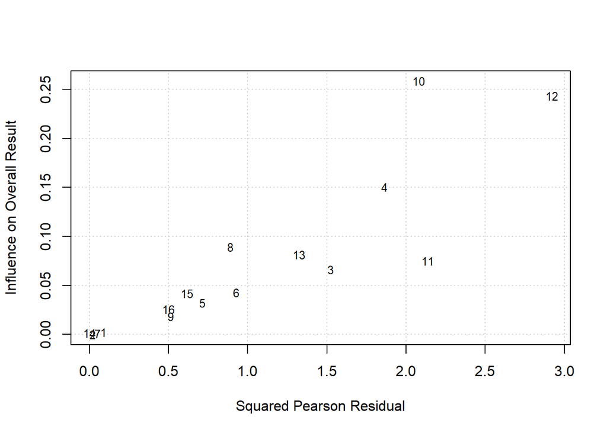

```r
baujat(b_res)
```

A set of diagnostics are also available to identify potential outliers and influential cases.

```r
inf <- influence(res)
print(inf)
```

```
##
##                           rstudent  dffits cook.d  cov.r tau2.del  QE.del
## Axelsson et al., 2009       0.2918  0.0485 0.0025 1.1331   0.0091 37.7109
## Axelsson et al., 2011       0.1196 -0.0031 0.0000 1.2595   0.0100 36.7672
## Bruce et al., 2010          1.2740  0.2595 0.0660 0.9942   0.0075 35.3930
## Christensen et al., 1999    1.4711  0.3946 0.1439 0.9544   0.0068 33.5886
## Christensen & Smith, 1995   0.8622  0.1838 0.0339 1.0505   0.0082 36.5396
## Cohen et al., 2004         -0.9795 -0.2121 0.0455 1.0639   0.0084 37.1703
## Dobbels et al., 2005        0.2177  0.0296 0.0010 1.1740   0.0094 37.6797
## Ediger et al., 2007        -0.9774 -0.3120 0.1001 1.1215   0.0084 36.1484
## Insel et al., 2006          0.7264  0.1392 0.0195 1.0561   0.0083 37.0495
## Jerant et al., 2011        -1.8667 -0.5861 0.2198 0.8502   0.0047 25.0661
## Moran et al., 1997         -1.4985 -0.2771 0.0756 1.0073   0.0077 35.6617
## O'Cleirigh et al., 2007     1.8776  0.4918 0.2148 0.8819   0.0059 31.9021
## Penedo et al., 2003        -1.1892 -0.2939 0.0859 1.0550   0.0080 36.3291
## Quine et al., 2012         -0.0020 -0.0423 0.0021 1.2524   0.0100 37.7339
## Stilley et al., 2004        0.8066  0.2126 0.0459 1.0907   0.0083 35.8385
## Wiebe & Christensen, 1997  -0.7160 -0.1656 0.0280 1.0853   0.0087 37.7017
##                              hat  weight    dfbs inf
## Axelsson et al., 2009     0.0568  5.6776  0.0481
## Axelsson et al., 2011     0.1054 10.5396 -0.0032
## Bruce et al., 2010        0.0364  3.6432  0.2623
## Christensen et al., 1999  0.0562  5.6195  0.3994
## Christensen & Smith, 1995 0.0441  4.4069  0.1837
## Cohen et al., 2004        0.0411  4.1094 -0.2112
## Dobbels et al., 2005      0.0714  7.1362  0.0296
## Ediger et al., 2007       0.0889  8.8886 -0.3128
## Insel et al., 2006        0.0379  3.7886  0.1387
## Jerant et al., 2011       0.1058 10.5826 -0.5430
## Moran et al., 1997        0.0369  3.6922 -0.2791
## O'Cleirigh et al., 2007   0.0511  5.1150  0.5059
## Penedo et al., 2003       0.0587  5.8732 -0.2941
## Quine et al., 2012        0.0998  9.9778 -0.0434
## Stilley et al., 2004      0.0684  6.8403  0.2125
## Wiebe & Christensen, 1997 0.0411  4.1094 -0.1642
```

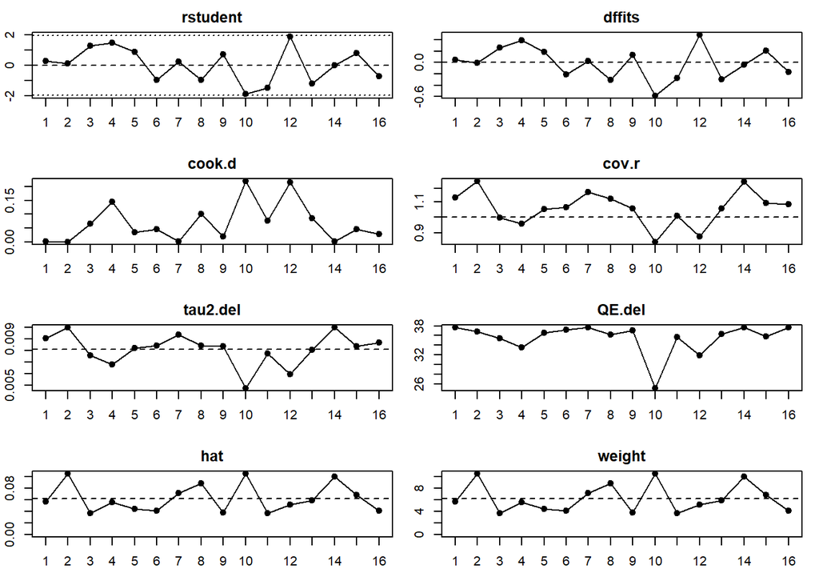

```r
plot(inf)
```

The plot visualizes the printed dataset. As there are no studies are marked with an asterisk in the printed dataset, none of the studies fulfilled the criteria as an influential study.

## Forest Plot

Now we visualize the meta-analysis with a forest plot.

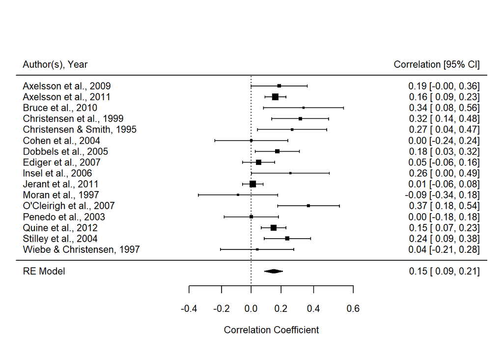

```r
forest(res, xlim=c(-1.6,1.6), atransf=transf.ztor,
       at=transf.rtoz(c(-.4,-.2,0,.2,.4,.6)), digits=c(2,1), cex=.8)
text(-1.6, 18, "Author(s), Year", pos=4, cex=.8)
text( 1.6, 18, "Correlation [95% CI]", pos=2, cex=.8)
```

We’ve created a plot with all 16 studies. Importantly, the correlations and 95% CIs are reported for each study as well as the summary effect size (the polygon at the bottom).  
The edges of the polygon represent the 95% confidence limit. Note the different sizes of each square - the studies with larger squares contributed more to the summary effect size.

## Publication Bias

In this section we will see:

- Funnel Plot
- Tests for bias: Egger’s regression test and Rank correlation test
- Fail-Safe *N* Analysis (or File Drawer Analysis)
- Trimm and Fill procedure

### Funnel Plot

We visualize the **Funnel Plot** through the following code.

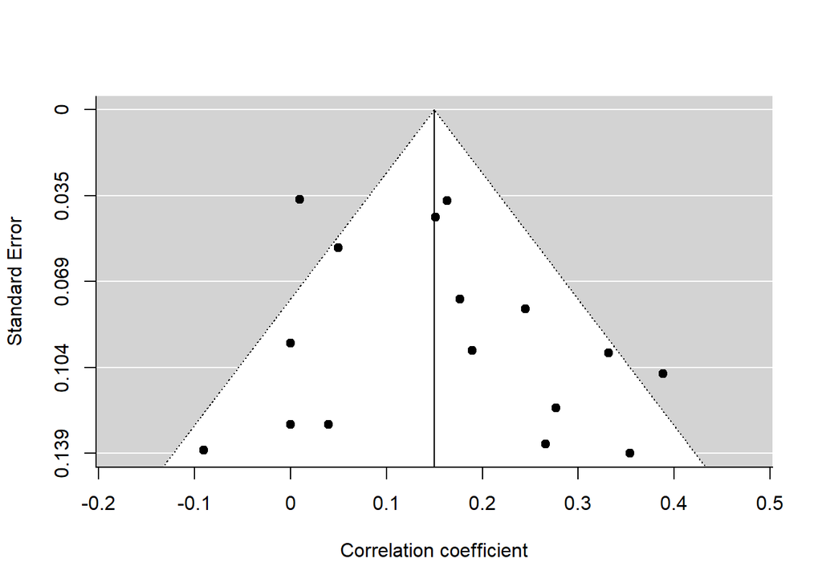

```r
funnel(res, xlab = "Correlation coefficient")
```

### Tests for bias (Egger’s regression test and Rank correlation test)

Then, we run two tests for bias: the **Egger’s regression test** and the **Rank correlation test**

```r
regtest(res)
```

```
##
## Regression Test for Funnel Plot Asymmetry
##
## model:     mixed-effects meta-regression model
## predictor: standard error
##
## test for funnel plot asymmetry: z = 1.0216, p = 0.3070
```

```r
ranktest(res)
```

```
##
## Rank Correlation Test for Funnel Plot Asymmetry
##
## Kendall's tau = 0.1590, p = 0.3918
```

Neither Egger’s regression test (*p* = 0.3071) or the Rank correlation test (*p* = 0.3918) was statistically significant so there’s no evidence of publication bias according to these tests.

### Fail-Safe *N* Analysis

In what follows, we see the code for the **Fail-Safe *N* Analysis**

```r
fsn(yi, vi, data = dat, type="Rosenthal", alpha=.05)
```

```
##
## Fail-safe N Calculation Using the Rosenthal Approach
##
## Observed Significance Level: <.0001
## Target Significance Level:   0.05
##
## Fail-safe N: 316
```

As it can be seen from result, we need 316 studies to reach the target *p*-value (we set the threshold to .05). Recall that a fail-safe number lower than 5*k* + 10 is considered to attest problem of publication bias (Card , 2012, p. 270; Rosenthal, 1979). Given that the threshold with 16 studies (5*16+10= **90**) is lower than the Fail-Safe *N* we observed (**316**), then this is another proof of the lack of the risk of publication bias. However, this index has been widely criticized (see Card, 2012, p. 270, par. 1.2.4.b; Crocetti, 2016, p. 12; Field & Gillett, 2010, p. 686), so the suggestion is not to rely too much on it.

### Trimm and Fill procedure

```r
# Load and View the biased dataset
dat_bias <- read.csv("dat_bias.csv")
# View(dat_bias)
knitr::kable(dat_bias, caption = "Our biased dataset")
```

Our biased dataset

| authors | year | ni | ri | controls | design | a_measure | c_measure | meanage | quality | yi | vi |
| --- | --- | --- | --- | --- | --- | --- | --- | --- | --- | --- | --- |
| Axelsson et al. | 2009 | 109 | 0.187 | none | cross-sectional | self-report | other | 22.00 | 1 | 0.1892266 | 0.0094340 |
| Axelsson et al. | 2011 | 749 | 0.162 | none | cross-sectional | self-report | NEO | 53.59 | 1 | 0.1634399 | 0.0013405 |
| Bruce et al. | 2010 | 55 | 0.340 | none | prospective | other | NEO | 43.36 | 2 | 0.3540925 | 0.0192308 |
| Christensen et al. | 1999 | 107 | 0.320 | none | cross-sectional | self-report | other | 41.70 | 1 | 0.3316471 | 0.0096154 |
| Christensen & Smith | 1995 | 72 | 0.270 | none | prospective | other | NEO | 46.39 | 2 | 0.2768638 | 0.0144928 |
| Dobbels et al. | 2005 | 174 | 0.175 | none | cross-sectional | self-report | NEO | 52.30 | 1 | 0.1768200 | 0.0058480 |
| Ediger et al. | 2007 | 326 | 0.050 | multiple | prospective | self-report | NEO | 41.00 | 3 | 0.0500417 | 0.0030960 |
| Insel et al. | 2006 | 58 | 0.260 | none | prospective | other | other | 77.00 | 2 | 0.2661084 | 0.0181818 |
| Jerant et al. | 2011 | 771 | 0.010 | multiple | prospective | other | NEO | 78.60 | 3 | 0.0100003 | 0.0013021 |
| O’Cleirigh et al. | 2007 | 91 | 0.370 | none | prospective | self-report | NEO | 37.90 | 2 | 0.3884231 | 0.0113636 |
| Quine et al. | 2012 | 537 | 0.150 | none | prospective | self-report | other | 69.00 | 2 | 0.1511404 | 0.0018727 |
| Stilley et al. | 2004 | 158 | 0.240 | none | prospective | other | NEO | 46.20 | 3 | 0.2447741 | 0.0064516 |

```r
# Run a meta-analysis with random effect on the new dataset
res.b <- rma(yi, vi, data=dat_bias)
res.b
```

```
##
## Random-Effects Model (k = 12; tau^2 estimator: REML)
##
## tau^2 (estimated amount of total heterogeneity): 0.0084 (SE = 0.0061)
## tau (square root of estimated tau^2 value):      0.0916
## I^2 (total heterogeneity / total variability):   66.94%
## H^2 (total variability / sampling variability):  3.03
##
## Test for Heterogeneity:
## Q(df = 11) = 32.0384, p-val = 0.0008
##
## Model Results:
##
## estimate      se    zval    pval   ci.lb   ci.ub
##   0.1850  0.0352  5.2591  <.0001  0.1160  0.2539  ***
##
## ---
## Signif. codes:  0 '***' 0.001 '**' 0.01 '*' 0.05 '.' 0.1 ' ' 1
```

```r
confint(res.b)
```

```
##
##        estimate   ci.lb   ci.ub
## tau^2    0.0084  0.0014  0.0320
## tau      0.0916  0.0381  0.1788
## I^2(%)  66.9444 25.9341 88.5393
## H^2      3.0252  1.3501  8.7255
```

The next commands will print a funnel plot, perform Egger’s regression test and the rank correlation test for the biased dataset.

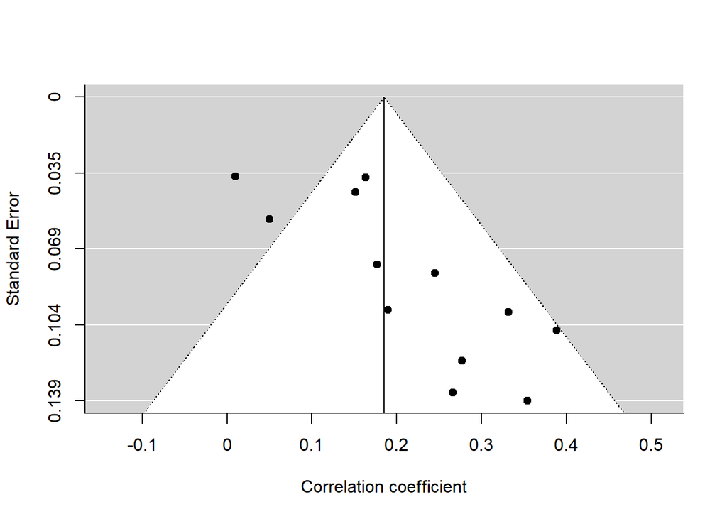

```r
funnel(res.b, xlab = "Correlation coefficient")
```

```r
regtest(res.b)
```

```
##
## Regression Test for Funnel Plot Asymmetry
##
## model:     mixed-effects meta-regression model
## predictor: standard error
##
## test for funnel plot asymmetry: z = 3.2615, p = 0.0011
```

```r
ranktest(res.b)
```

```
##
## Rank Correlation Test for Funnel Plot Asymmetry
##
## Kendall's tau = 0.5455, p = 0.0138
```

The trim and fill method imputes “missing” studies to create a more symmetrical funnel plot.

```r
res.tf <- trimfill(res.b)
res.tf
```

```
##
## Estimated number of missing studies on the left side: 5 (SE = 2.1916)
##
## Random-Effects Model (k = 17; tau^2 estimator: REML)
##
## tau^2 (estimated amount of total heterogeneity): 0.0134 (SE = 0.0075)
## tau (square root of estimated tau^2 value):      0.1155
## I^2 (total heterogeneity / total variability):   71.93%
## H^2 (total variability / sampling variability):  3.56
##
## Test for Heterogeneity:
## Q(df = 16) = 47.7575, p-val < .0001
##
## Model Results:
##
## estimate      se    zval    pval   ci.lb   ci.ub
##   0.1301  0.0359  3.6201  0.0003  0.0597  0.2006  ***
##
## ---
## Signif. codes:  0 '***' 0.001 '**' 0.01 '*' 0.05 '.' 0.1 ' ' 1
```

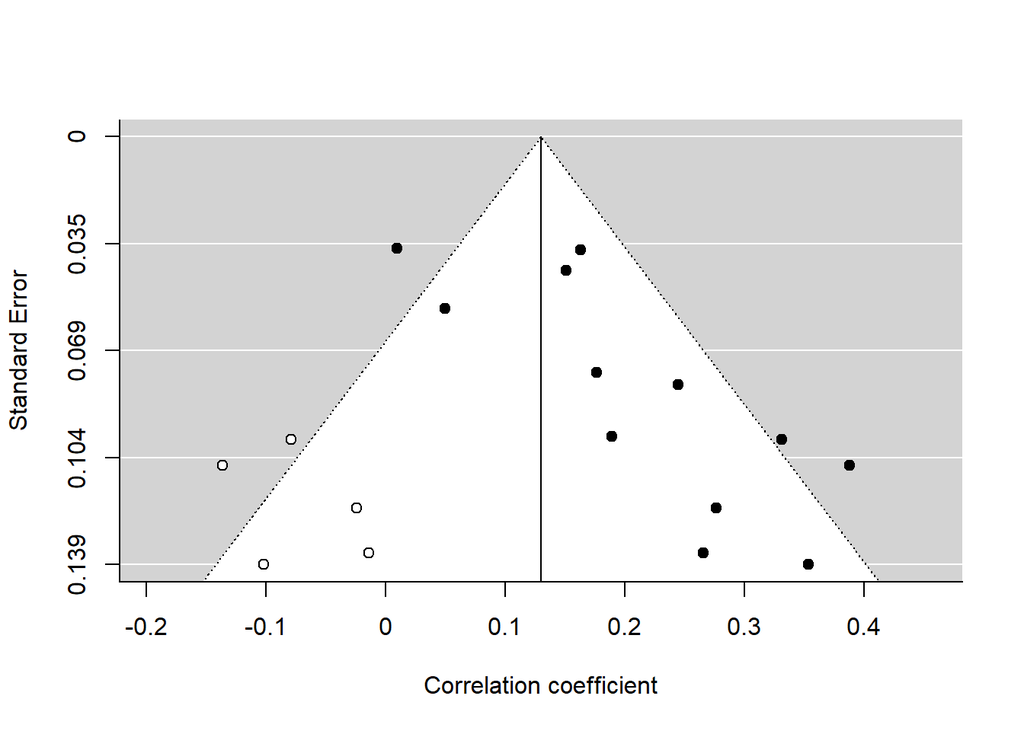

```r
funnel(res.tf, xlab = "Correlation coefficient")
```

We observe that the original effect size was **0.1850** [95%CI: 0.1160, 0.2539]. After we ran the trimm and fill analysis, the effect size was **0.1301** [95%CI: 0.0597, 0.2006]. Usually, if trivial differences between the observed and the estimated effect sizes were observed, then publication bias (albeit present) should not be a serious threat to our results (Duval, 2005). In this example, the two effect sizes are close and both significant, hence (with caution) we can conclude that publication bias does not affect our results.

## Moderator Analyses

Moderating effect of **age**.

```r
res.modage <- rma(yi, vi, mods = ~ meanage, data=dat)
res.modage
```

```
##
## Mixed-Effects Model (k = 16; tau^2 estimator: REML)
##
## tau^2 (estimated amount of residual heterogeneity):     0.0072 (SE = 0.0054)
## tau (square root of estimated tau^2 value):             0.0846
## I^2 (residual heterogeneity / unaccounted variability): 56.50%
## H^2 (unaccounted variability / sampling variability):   2.30
## R^2 (amount of heterogeneity accounted for):            11.76%
##
## Test for Residual Heterogeneity:
## QE(df = 14) = 30.9050, p-val = 0.0057
##
## Test of Moderators (coefficient 2):
## QM(df = 1) = 1.4286, p-val = 0.2320
##
## Model Results:
##
##          estimate      se     zval    pval    ci.lb   ci.ub
## intrcpt    0.2741  0.1090   2.5147  0.0119   0.0605  0.4877  *
## meanage   -0.0024  0.0020  -1.1952  0.2320  -0.0063  0.0015
##
## ---
## Signif. codes:  0 '***' 0.001 '**' 0.01 '*' 0.05 '.' 0.1 ' ' 1
```

The data under the “Test of Moderators” line provides the information needed. As the p value was greater than 0.05, this provides evidence that age did not significantly moderate the observed correlation.

Moderator for **methodological quality**

```r
res.modq <- rma(yi, vi, mods = ~ quality, data=dat)
res.modq
```

```
##
## Mixed-Effects Model (k = 16; tau^2 estimator: REML)
##
## tau^2 (estimated amount of residual heterogeneity):     0.0078 (SE = 0.0057)
## tau (square root of estimated tau^2 value):             0.0884
## I^2 (residual heterogeneity / unaccounted variability): 57.79%
## H^2 (unaccounted variability / sampling variability):   2.37
## R^2 (amount of heterogeneity accounted for):            3.73%
##
## Test for Residual Heterogeneity:
## QE(df = 14) = 30.4205, p-val = 0.0067
##
## Test of Moderators (coefficient 2):
## QM(df = 1) = 0.6393, p-val = 0.4240
##
## Model Results:
##
##          estimate      se     zval    pval    ci.lb   ci.ub
## intrcpt    0.2082  0.0796   2.6149  0.0089   0.0521  0.3643  **
## quality   -0.0312  0.0391  -0.7995  0.4240  -0.1078  0.0453
##
## ---
## Signif. codes:  0 '***' 0.001 '**' 0.01 '*' 0.05 '.' 0.1 ' ' 1
```

As the p value was greater than 0.05, this provides evidence that methodological quality did not significantly moderate the observed correlation.

Now, to look at a **categorical variable**. Here we look at the moderating effect of whether variables were controlled for.

```r
res.mes <- rma(yi, vi, mods = ~ factor(controls), data=dat)
res.mes
```

```
##
## Mixed-Effects Model (k = 16; tau^2 estimator: REML)
##
## tau^2 (estimated amount of residual heterogeneity):     0.0000 (SE = 0.0015)
## tau (square root of estimated tau^2 value):             0.0002
## I^2 (residual heterogeneity / unaccounted variability): 0.00%
## H^2 (unaccounted variability / sampling variability):   1.00
## R^2 (amount of heterogeneity accounted for):            100.00%
##
## Test for Residual Heterogeneity:
## QE(df = 14) = 18.0370, p-val = 0.2051
##
## Test of Moderators (coefficient 2):
## QM(df = 1) = 20.1221, p-val < .0001
##
## Model Results:
##
##                       estimate      se    zval    pval    ci.lb   ci.ub
## intrcpt                 0.0167  0.0296  0.5635  0.5731  -0.0413  0.0746
## factor(controls)none    0.1621  0.0361  4.4858  <.0001   0.0913  0.2329  ***
##
## ---
## Signif. codes:  0 '***' 0.001 '**' 0.01 '*' 0.05 '.' 0.1 ' ' 1
```

As the *p* value was less than 0.05, this provides evidence that controlling for variables significantly moderates the observed correlation.

Accounting for multiple effect sizes from individual studies using robust variation estimation.  
First we import a data set aggregating the first 3 studies from the original dataset.  
As mentioed above, this command will only work if the “dat_mes” file is located in your working directory.

```r
dat_mes <- read.csv("dat_mes.csv")
#View(dat_mes)
knitr::kable(dat_mes, caption = "Our new dataset")
```

Our new dataset

| id | Publication.Year | n | r | Variables.controlled | Study.design | Adherence.measure | Conscientiousness.measure | Mean.age | Methodological.quality |
| --- | --- | --- | --- | --- | --- | --- | --- | --- | --- |
| Axelsson et al. | 2009 | 109 | 0.187 | none | cross-sectional | self-report | other | 22.00 | 1 |
| Axelsson et al. | 2011 | 749 | 0.162 | none | cross-sectional | self-report | NEO | 53.59 | 1 |
| Axelsson et al. | 2010 | 55 | 0.340 | none | prospective | other | NEO | 43.36 | 2 |
| Christensen et al. | 1999 | 107 | 0.320 | none | cross-sectional | self-report | other | 41.70 | 1 |
| Christensen & Smith | 1995 | 72 | 0.270 | none | prospective | other | NEO | 46.39 | 2 |
| Cohen et al. | 2004 | 65 | 0.000 | none | prospective | other | NEO | 41.20 | 2 |
| Dobbels et al. | 2005 | 174 | 0.175 | none | cross-sectional | self-report | NEO | 52.30 | 1 |
| Ediger et al. | 2007 | 326 | 0.050 | multiple | prospective | self-report | NEO | 41.00 | 3 |
| Insel et al. | 2006 | 58 | 0.260 | none | prospective | other | other | 77.00 | 2 |
| Jerant et al. | 2011 | 771 | 0.010 | multiple | prospective | other | NEO | 78.60 | 3 |
| Moran et al. | 1997 | 56 | -0.090 | multiple | prospective | other | NEO | 57.20 | 2 |
| O’Cleirigh et al. | 2007 | 91 | 0.370 | none | prospective | self-report | NEO | 37.90 | 2 |
| Penedo et al. | 2003 | 116 | 0.000 | none | cross-sectional | self-report | NEO | 39.20 | 1 |
| Quine et al. | 2012 | 537 | 0.150 | none | prospective | self-report | other | 69.00 | 2 |
| Stilley et al. | 2004 | 158 | 0.240 | none | prospective | other | NEO | 46.20 | 3 |
| Wiebe & Christensen | 1997 | 65 | 0.040 | none | prospective | other | NEO | 56.00 | 1 |

Calculate the effect size and effect size variances

```r
dat_mes <- escalc(measure="ZCOR", ri=r, ni=n, data=dat_mes)
```

Fit the meta-regression model with correction for small sample size

```r
mes_ss <-  robu(formula = yi ~ 1, data = dat_mes, studynum = id, var.eff.size = vi, modelweights = "HIER", small = TRUE)
print(mes_ss)
```

```
## RVE: Hierarchical Effects Model with Small-Sample Corrections
##
## Model: yi ~ 1
##
## Number of clusters = 14
## Number of outcomes = 16 (min = 1 , mean = 1.14 , median = 1 , max = 3 )
## Omega.sq = 0
## Tau.sq = 0.007952589
##
##                Estimate StdErr t-value  dfs P(|t|>) 95% CI.L 95% CI.U Sig
## 1 X.Intercept.     0.15 0.0329    4.55 9.51 0.00121   0.0759    0.224 ***
## ---
## Signif. codes: < .01 *** < .05 ** < .10 *
## ---
## Note: If df < 4, do not trust the results
```

The output confirms that there were 16 effect sizes from 14 studies. Analysis indicates a statistically significant point estimate [0.15; 95% CI (0.08, 0.22), p = 0.001].